# Latihan 1 MPDW

Lutfi Syahreza Lubis

2023-09-02

## Library

```r
library("forecast")
```

```r
library("graphics")
library("TTR")
library("TSA")
```

## Importing Data

```r
library(rio)
data_air <- import("https://raw.githubusercontent.com/lutfi-reza/mpdw-lutfi-reza/main/data/data_air.csv")
```

## Eksplorasi Data/ Exploratory Data Analysis

```r
View(data_air)
str(data_air)
```

```
## 'data.frame':    334 obs. of  2 variables:
##  $ periode   : int  1 2 3 4 5 6 7 8 9 10 ...
##  $ tinggi_air: int  1900 1870 1750 1390 1850 1760 2010 1880 1680 1560 ...
```

```r
dim(data_air)
```

```
## [1] 334   2
```

These function: View, str, dim are used to show the dataset, type, and the dimension of the dataset, sequentially.

Fungsi-fungsi ini bertujuan untuk menampilkan data, menunjukkan jenis dan ukuran data.

### Mengubah data agar terbaca sebagai data deret waktu dengan fungsi `ts()` .

```r
data_air.ts <- ts(data_air$tinggi_air)
```

The `ts` function is used to read the dataset as time series data

### Menampilkan ringkasan data

```r
summary(data_air.ts)
```

```
##    Min. 1st Qu.  Median    Mean 3rd Qu.    Max.
##    1210    1640    1760    1754    1878    2310
```

### Membuat plot deret waktu data

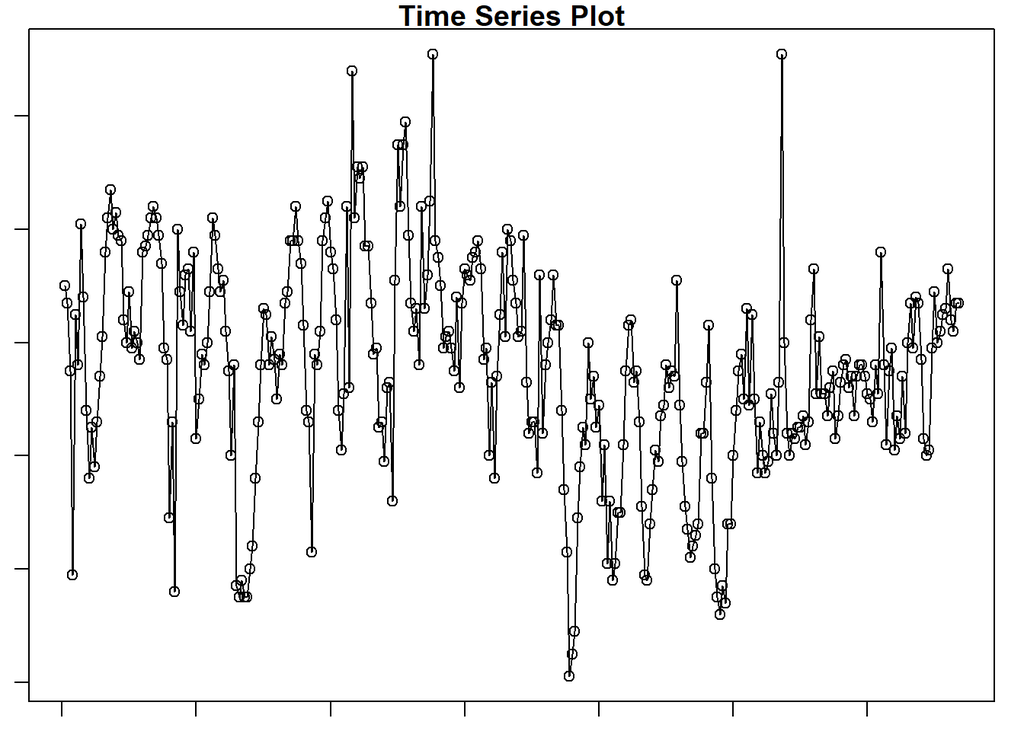

```r
par(mar = c(1, 1, 1, 1))
ts.plot(data_air.ts, xlab="Time Period ", ylab="Reading",
        main = "Time Series Plot")
points(data_air.ts)
```

The plot above indicates that the time series data exhibits a constant pattern.

Plot di atas menunjukkan bahwa data time series memiliki pola konstan.

### Membagi data per bulan/ Monthly data

```r
januari <- data_air[1:29,]
februari <- data_air[30:53,]
maret <- data_air[54:84,]
april <- data_air[85:101,]
mei <- data_air[102:128,]
juni <- data_air[129:158,]
juli <- data_air[159:189,]
agustus <- data_air[190:220,]
september <- data_air[221:250,]
oktober <- data_air[251:280,]
november <- data_air[281:304,]
desember <- data_air[305:334,]
```

To read the dataset as time series data Membuat data menjadi time series

```r
januari.ts <- ts((data_air[1:29,])$tinggi_air)
februari.ts <- ts((data_air[30:53,])$tinggi_air)
maret.ts  <- ts((data_air[54:84,])$tinggi_air)
april.ts  <-ts(( data_air[85:101,])$tinggi_air)
mei.ts  <- ts((data_air[102:128,])$tinggi_air)
juni.ts  <- ts((data_air[129:158,])$tinggi_air)
juli.ts  <- ts((data_air[159:189,])$tinggi_air)
agustus.ts  <- ts((data_air[190:220,])$tinggi_air)
september.ts  <- ts((data_air[221:250,])$tinggi_air)
oktober.ts  <- ts((data_air[251:280,])$tinggi_air)
november.ts  <- ts((data_air[281:304,])$tinggi_air)
desember.ts  <- ts((data_air[305:334,])$tinggi_air)
```

### Eksplorasi data per bulan/ Monthly expploratory data analysis

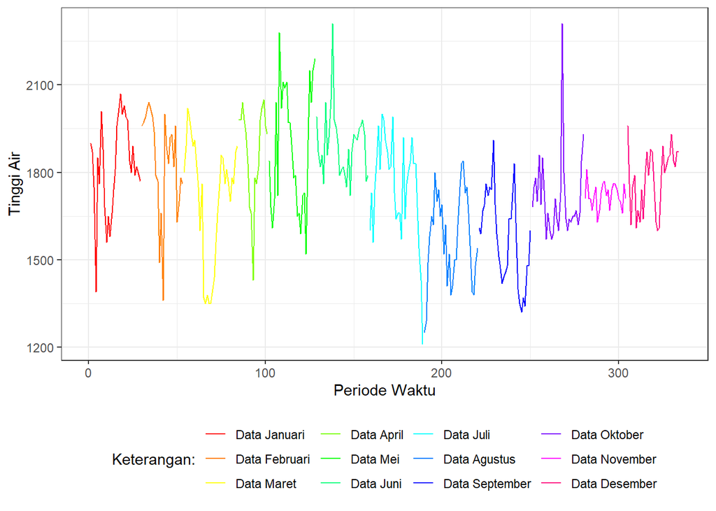

```r
#Eksplorasi dengan GGPLOT per bulan
library(ggplot2)
ggplot() +
  geom_line(data = januari, aes(x = periode, y = tinggi_air, col = "Data Januari")) +
  geom_line(data = februari, aes(x = periode, y = tinggi_air, col = "Data Februari")) +
  geom_line(data = maret, aes(x = periode, y = tinggi_air, col = "Data Maret")) +
  geom_line(data = april, aes(x = periode, y = tinggi_air, col = "Data April")) +
  geom_line(data = mei, aes(x = periode, y = tinggi_air, col = "Data Mei")) +
  geom_line(data = juni, aes(x = periode, y = tinggi_air, col = "Data Juni")) +
  geom_line(data = juli, aes(x = periode, y = tinggi_air, col = "Data Juli")) +
  geom_line(data = agustus, aes(x = periode, y = tinggi_air, col = "Data Agustus")) +
  geom_line(data = september, aes(x = periode, y = tinggi_air, col = "Data September")) +
  geom_line(data = oktober, aes(x = periode, y = tinggi_air, col = "Data Oktober")) +
  geom_line(data = november, aes(x = periode, y = tinggi_air, col = "Data November")) +
  geom_line(data = desember, aes(x = periode, y = tinggi_air, col = "Data Desember")) +
  labs(x = "Periode Waktu", y = "Tinggi Air", color = "Legend") +
  scale_colour_manual(name="Keterangan:", breaks = c("Data Januari", "Data Februari","Data Maret","Data April", "Data Mei", "Data Juni", "Data Juli", "Data Agustus", "Data September","Data Oktober", "Data November", "Data Desember"),
                      values = rainbow(12)) +
  theme_bw() + theme(legend.position = "bottom",
                     plot.caption = element_text(hjust=0.5, size=12))
```

The plot above doesn’t indicate any trend.

Plot data di atas menunjukkan bahwa data per bulan menyebar secara konstan, tidak terlihat adanya tren atau musim pada data.

## Single Moving Average

### Pembagian Data

Dividing the dataset into a 80 percent of training data and 20 percent of testing data.

Pembagian data latih dan data uji dilakukan dengan perbandingan 80% data latih dan 20% data uji.

```r
#Membagi data training dan testing
data_training <- data_air[1:267,]
data_testing <- data_air[268:334,]

#Membuat plot deret waktu data dari data training dan testing
training.ts <- ts(data_training$tinggi_air)
testing.ts <- ts(data_testing$tinggi_air)
```

### Eksplorasi data training dan testing

Exploratory analysis on the dataset thoroughly, training data, and testing data.

Eksplorasi dilakukan pada seluruh data, data training, dan data testing.

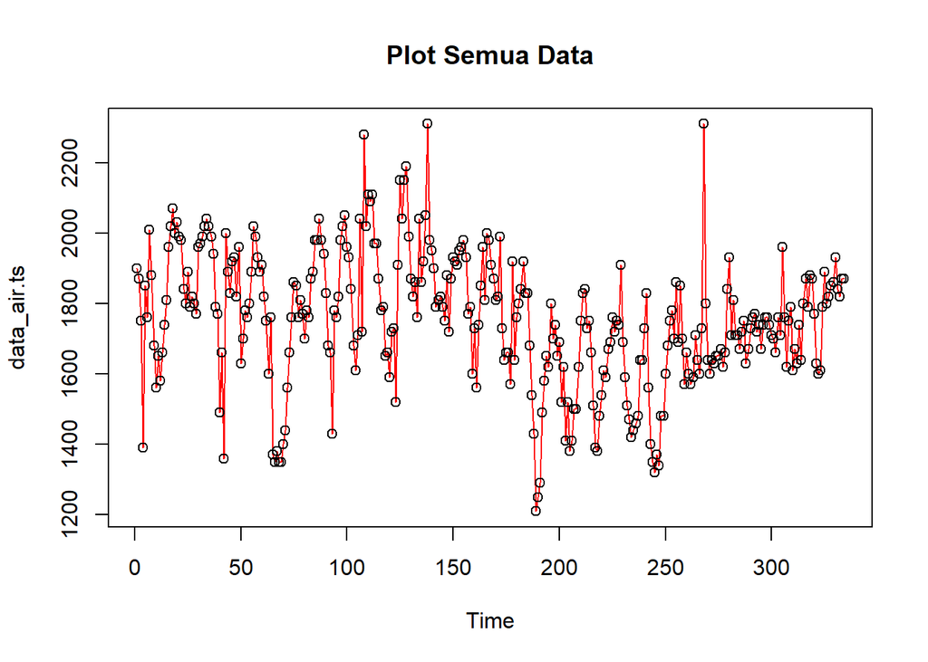

```r
#Eksplorasi keseluruhan data
plot(data_air.ts, col="red",main="Plot Semua Data")
points(data_air.ts)
```

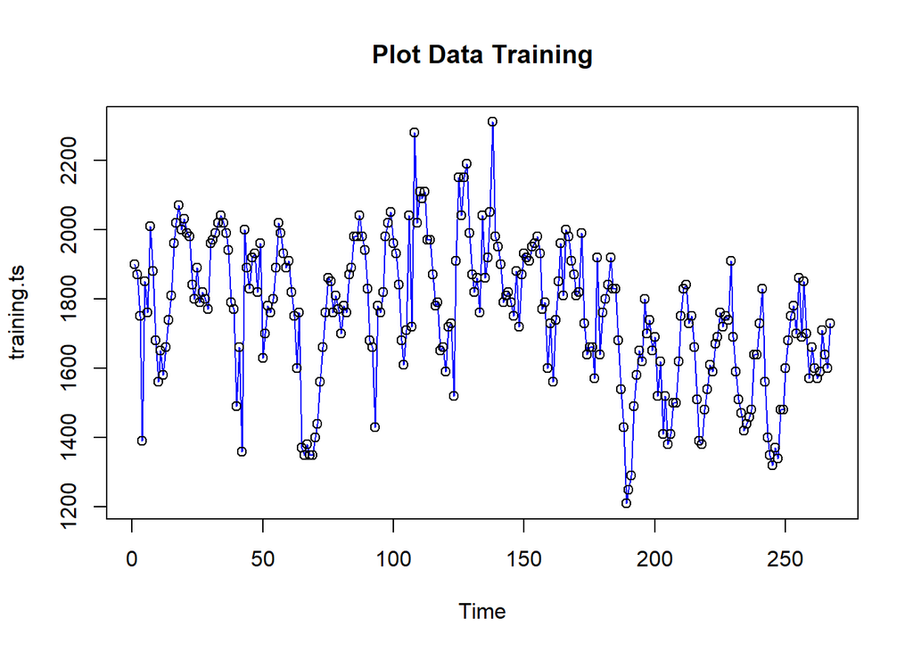

```r
#Eksplorasi data latih (training)
plot(training.ts, col="blue",main="Plot Data Training")
points(training.ts)
```

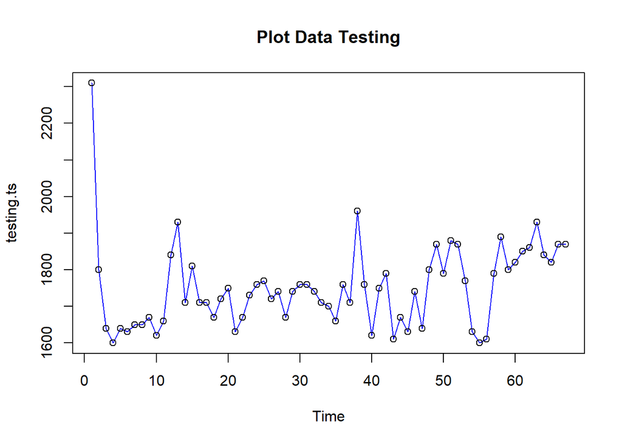

```r
#Eksplorasi data uji (test)
plot(testing.ts, col="blue",main="Plot Data Testing")
points(testing.ts)
```

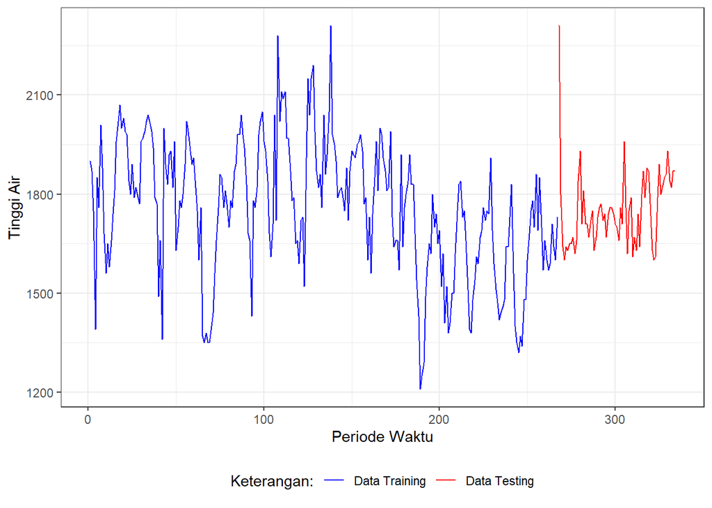

```r
#Eksplorasi dengan GGPLOT
library(ggplot2)
ggplot() +
  geom_line(data = data_training, aes(x = periode, y = tinggi_air, col = "Data Training")) +
  geom_line(data = data_testing, aes(x = periode, y = tinggi_air, col = "Data Testing")) +
  labs(x = "Periode Waktu", y = "Tinggi Air", color = "Legend") +
  scale_colour_manual(name="Keterangan:", breaks = c("Data Training", "Data Testing"),
                      values = c("blue", "red")) +
  theme_bw() + theme(legend.position = "bottom",
                     plot.caption = element_text(hjust=0.5, size=12))
```

### Single Moving Average (SMA)

The SMA methods is suitable for constant pattern of time series data.

Metode SMA cocok digunakan untuk data konstan.

```r
data.sma <- SMA(training.ts)
data.sma
```

```
## Time Series:
## Start = 1
## End = 267
## Frequency = 1
##   [1]   NA   NA   NA   NA   NA   NA   NA   NA   NA 1765 1740 1711 1702 1737 1733
##  [16] 1753 1754 1773 1805 1852 1886 1926 1944 1950 1958 1941 1921 1894 1871 1864
##  [31] 1862 1863 1881 1905 1918 1938 1950 1949 1949 1902 1871 1808 1806 1791 1772
##  [46] 1765 1764 1767 1786 1800 1804 1846 1822 1813 1819 1829 1835 1846 1839 1867
##  [61] 1879 1876 1860 1856 1804 1737 1676 1618 1564 1513 1475 1456 1462 1462 1511
##  [76] 1561 1599 1645 1687 1717 1751 1771 1792 1805 1817 1830 1858 1875 1892 1905
##  [91] 1895 1885 1841 1830 1808 1792 1786 1790 1801 1814 1839 1857 1882 1865 1860
## [106] 1882 1856 1882 1879 1894 1910 1937 1966 2002 2018 1992 1999 1936 1900 1848
## [121] 1811 1773 1728 1722 1750 1776 1812 1866 1899 1927 1937 1950 1974 1987 1958
## [136] 1946 1936 1948 1947 1955 1963 1956 1961 1939 1932 1915 1898 1839 1828 1826
## [151] 1828 1840 1854 1868 1887 1905 1894 1901 1874 1854 1818 1801 1791 1791 1774
## [166] 1781 1802 1814 1841 1849 1875 1900 1888 1856 1841 1807 1766 1767 1744 1739
## [181] 1737 1722 1741 1760 1777 1779 1776 1727 1684 1633 1582 1547 1513 1495 1474
## [196] 1486 1502 1533 1577 1621 1644 1657 1640 1627 1603 1564 1544 1520 1517 1523
## [211] 1554 1576 1608 1631 1659 1669 1658 1646 1632 1611 1589 1564 1558 1552 1562
## [226] 1583 1619 1655 1698 1713 1711 1703 1683 1656 1624 1598 1571 1561 1534 1538
## [241] 1562 1567 1560 1553 1541 1532 1518 1502 1486 1473 1458 1477 1515 1550 1604
## [256] 1636 1687 1709 1718 1724 1716 1698 1679 1680 1658 1649 1637
```

```r
data.ramal <- c(NA,data.sma)
data.ramal #forecast 1 periode ke depan
```

```
##   [1]   NA   NA   NA   NA   NA   NA   NA   NA   NA   NA 1765 1740 1711 1702 1737
##  [16] 1733 1753 1754 1773 1805 1852 1886 1926 1944 1950 1958 1941 1921 1894 1871
##  [31] 1864 1862 1863 1881 1905 1918 1938 1950 1949 1949 1902 1871 1808 1806 1791
##  [46] 1772 1765 1764 1767 1786 1800 1804 1846 1822 1813 1819 1829 1835 1846 1839
##  [61] 1867 1879 1876 1860 1856 1804 1737 1676 1618 1564 1513 1475 1456 1462 1462
##  [76] 1511 1561 1599 1645 1687 1717 1751 1771 1792 1805 1817 1830 1858 1875 1892
##  [91] 1905 1895 1885 1841 1830 1808 1792 1786 1790 1801 1814 1839 1857 1882 1865
## [106] 1860 1882 1856 1882 1879 1894 1910 1937 1966 2002 2018 1992 1999 1936 1900
## [121] 1848 1811 1773 1728 1722 1750 1776 1812 1866 1899 1927 1937 1950 1974 1987
## [136] 1958 1946 1936 1948 1947 1955 1963 1956 1961 1939 1932 1915 1898 1839 1828
## [151] 1826 1828 1840 1854 1868 1887 1905 1894 1901 1874 1854 1818 1801 1791 1791
## [166] 1774 1781 1802 1814 1841 1849 1875 1900 1888 1856 1841 1807 1766 1767 1744
## [181] 1739 1737 1722 1741 1760 1777 1779 1776 1727 1684 1633 1582 1547 1513 1495
## [196] 1474 1486 1502 1533 1577 1621 1644 1657 1640 1627 1603 1564 1544 1520 1517
## [211] 1523 1554 1576 1608 1631 1659 1669 1658 1646 1632 1611 1589 1564 1558 1552
## [226] 1562 1583 1619 1655 1698 1713 1711 1703 1683 1656 1624 1598 1571 1561 1534
## [241] 1538 1562 1567 1560 1553 1541 1532 1518 1502 1486 1473 1458 1477 1515 1550
## [256] 1604 1636 1687 1709 1718 1724 1716 1698 1679 1680 1658 1649 1637
```

### Peramalan ke 67 periode ke depan (sejumlah data testing)

```r
data.gab<-cbind(aktual=c(training.ts,rep(NA,67)),pemulusan=c(data.sma,rep(NA,67)),ramalan=c(data.ramal,rep(data.ramal[length(data.ramal)],66)))
data.gab #forecast 67 periode ke depan
```

```
##        aktual pemulusan ramalan
##   [1,]   1900        NA      NA
##   [2,]   1870        NA      NA
##   [3,]   1750        NA      NA
##   [4,]   1390        NA      NA
##   [5,]   1850        NA      NA
##   [6,]   1760        NA      NA
##   [7,]   2010        NA      NA
##   [8,]   1880        NA      NA
##   [9,]   1680        NA      NA
##  [10,]   1560      1765      NA
##  [11,]   1650      1740    1765
##  [12,]   1580      1711    1740
##  [13,]   1660      1702    1711
##  [14,]   1740      1737    1702
```

[output cut: 320 more lines]

### Plot deret waktu data peramalan

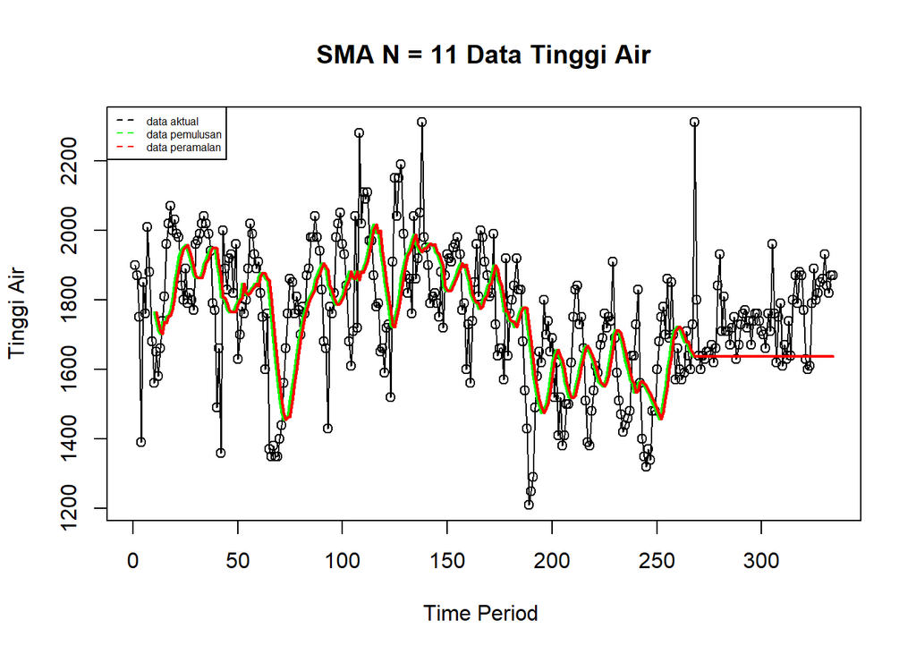

```r
ts.plot(data_air.ts, xlab="Time Period ", ylab="Tinggi Air", main= "SMA N = 11 Data Tinggi Air")
points(data_air.ts)
lines(data.gab[,2],col="green",lwd=2)
lines(data.gab[,3],col="red",lwd=2)
legend("topleft",c("data aktual","data pemulusan","data peramalan"), lty=8, col=c("black","green","red"), cex=0.5)
```

The following syntaxes are used to measure the accuracy using SSE, MSE, and MAPE on both traning and testing data.

Selanjutnya perhitungan akurasi dilakukan dengan ukuran akurasi *Sum Squares Error* (SSE), *Mean Square Error* (MSE) dan *Mean Absolute Percentage Error* (MAPE). Perhitungan akurasi dilakukan baik pada data latih maupun pada data uji.

```r
#Menghitung nilai keakuratan data traning
error_train.sma = training.ts-data.ramal[1:length(training.ts)]
SSE_train.sma = sum(error_train.sma[12:length(training.ts)]^2)
MSE_train.sma = mean(error_train.sma[12:length(training.ts)]^2)
MAPE_train.sma = mean(abs((error_train.sma[12:length(training.ts)]/training.ts[12:length(training.ts)])*100))

akurasi_train.sma <- matrix(c(SSE_train.sma, MSE_train.sma, MAPE_train.sma))
row.names(akurasi_train.sma)<- c("SSE", "MSE", "MAPE")
colnames(akurasi_train.sma) <- c("Akurasi m = 11")
akurasi_train.sma
```

```
##      Akurasi m = 11
## SSE    9.317678e+06
## MSE    3.639718e+04
## MAPE   9.348629e+00
```

```r
#Menghitung nilai keakuratan data uji
error_test.sma = testing.ts-data.gab[268:334,3]
SSE_test.sma = sum(error_test.sma^2)
MSE_test.sma = mean(error_test.sma^2)
MAPE_test.sma = mean(abs((error_test.sma/testing.ts*100)))

akurasi_test.sma <- matrix(c(SSE_test.sma, MSE_test.sma, MAPE_test.sma))
row.names(akurasi_test.sma)<- c("SSE", "MSE", "MAPE")
colnames(akurasi_test.sma) <- c("Akurasi m = 11")
akurasi_test.sma
```

```
##      Akurasi m = 11
## SSE    1.737403e+06
## MSE    2.593139e+04
## MAPE   6.468447e+00
```

## Single Exponential Smoothing

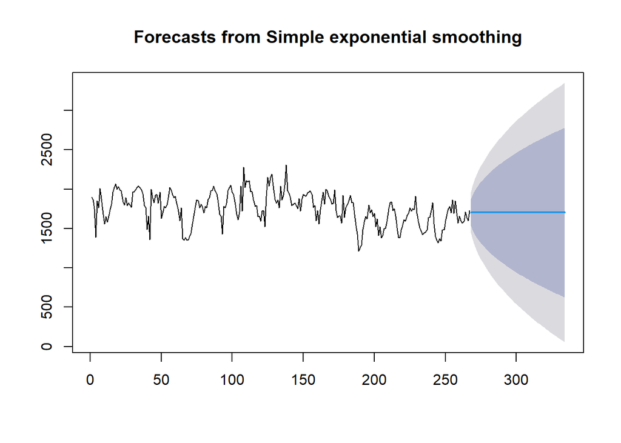

```r
#Cara 1 (fungsi ses)
ses1 <- ses(training.ts, h=67, alpha = NULL)
plot(ses1)
```

```r
ses1
```

```
##     Point Forecast     Lo 80    Hi 80      Lo 95    Hi 95
## 268       1702.414 1531.7680 1873.060 1441.43345 1963.395
## 269       1702.414 1487.3456 1917.483 1373.49527 2031.333
## 270       1702.414 1450.6428 1954.185 1317.36308 2087.465
## 271       1702.414 1418.6481 1986.180 1268.43140 2136.397
## 272       1702.414 1389.9121 2014.916 1224.48348 2180.345
## 273       1702.414 1363.6046 2041.224 1184.24968 2220.579
## 274       1702.414 1339.1976 2065.631 1146.92237 2257.906
## 275       1702.414 1316.3304 2088.498 1111.95009 2292.878
## 276       1702.414 1294.7439 2110.084 1078.93640 2325.892
## 277       1702.414 1274.2444 2130.584 1047.58501 2357.243
## 278       1702.414 1254.6824 2150.146 1017.66756 2387.161
## 279       1702.414 1235.9401 2168.888  989.00361 2415.825
## 280       1702.414 1217.9222 2186.906  961.44769 2443.381
## 281       1702.414 1200.5508 2204.277  934.88045 2469.948
```

[output cut: 53 more lines]

### Plot pemulusan data latih menggunakan SES

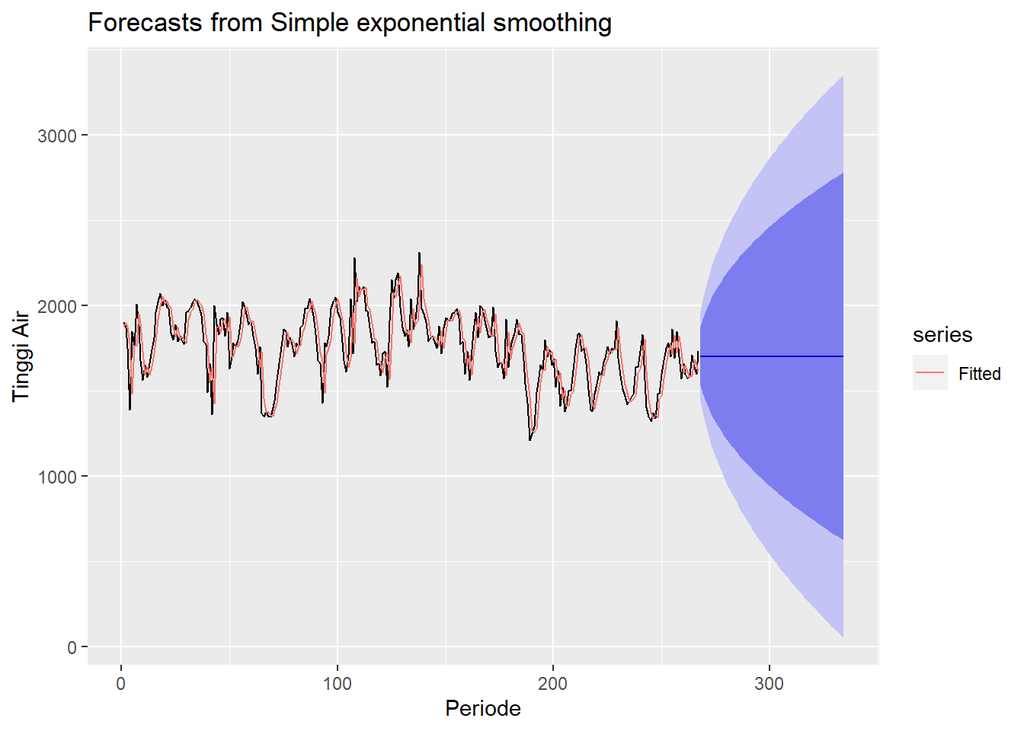

```r
autoplot(ses1) +
  autolayer(fitted(ses1), series="Fitted") +
  ylab("Tinggi Air") + xlab("Periode")
```

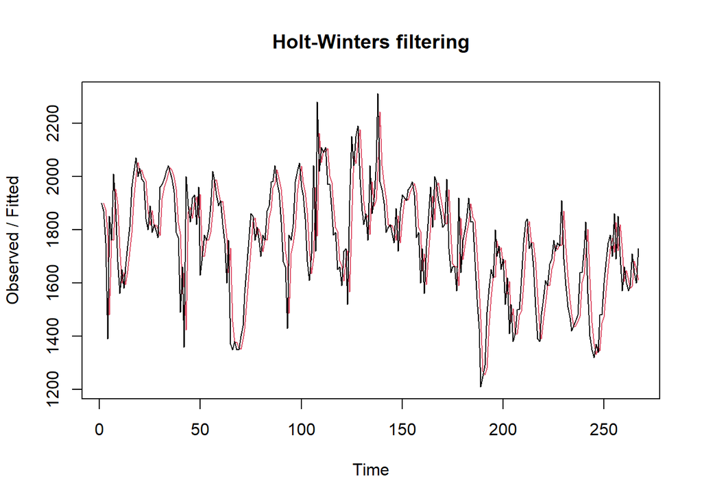

```r
#Cara 2 (fungsi Holtwinter)
ses2 <- HoltWinters(training.ts, gamma = FALSE, beta = FALSE, alpha = NULL)
plot(ses2)
```

```r
#ramalan
ramalan2<- forecast(ses1, h=67)
ramalan2
```

```
##     Point Forecast     Lo 80    Hi 80      Lo 95    Hi 95
## 268       1702.414 1531.7680 1873.060 1441.43345 1963.395
## 269       1702.414 1487.3456 1917.483 1373.49527 2031.333
## 270       1702.414 1450.6428 1954.185 1317.36308 2087.465
## 271       1702.414 1418.6481 1986.180 1268.43140 2136.397
## 272       1702.414 1389.9121 2014.916 1224.48348 2180.345
## 273       1702.414 1363.6046 2041.224 1184.24968 2220.579
## 274       1702.414 1339.1976 2065.631 1146.92237 2257.906
## 275       1702.414 1316.3304 2088.498 1111.95009 2292.878
## 276       1702.414 1294.7439 2110.084 1078.93640 2325.892
## 277       1702.414 1274.2444 2130.584 1047.58501 2357.243
## 278       1702.414 1254.6824 2150.146 1017.66756 2387.161
## 279       1702.414 1235.9401 2168.888  989.00361 2415.825
## 280       1702.414 1217.9222 2186.906  961.44769 2443.381
## 281       1702.414 1200.5508 2204.277  934.88045 2469.948
```

[output cut: 53 more lines]

#### Akurasi Data Training

```r
#Keakuratan Metode
#Pada data training
SSE2<-ses2$SSE
MSE2<-ses2$SSE/length(training.ts)
RMSE2<-sqrt(MSE2)

akurasi2 <- matrix(c(SSE2,MSE2,RMSE2))
row.names(akurasi2)<- c("SSE", "MSE", "RMSE")
colnames(akurasi2) <- c("Akurasi lamda = NULL")
akurasi2
```

```
##      Akurasi lamda = NULL
## SSE          4698871.6870
## MSE            17598.7704
## RMSE             132.6604
```

#### Akurasi Data Testing

```r
selisih2<-ramalan2$mean-data_testing$tinggi_air
SSEtesting2<-sum(selisih2^2)
MSEtesting2<-SSEtesting2/length(data_testing)

akurasitesting2 <- matrix(c(MSEtesting2))
row.names(akurasitesting2)<- c("MSE2")
akurasitesting2
```

```
##          [,1]
## MSE2 514835.6
```

```r
#Menggunakan fungsi `accuracy`
accuracy(ramalan2, data_testing$tinggi_air)
```

```
##                      ME     RMSE      MAE        MPE     MAPE      MASE
## Training set -0.8823167 132.6562 100.0806 -0.4139928 5.793112 0.9922269
## Test set     48.0336601 123.9686  89.3926  2.3647730 4.900716 0.8862628
##                     ACF1
## Training set -0.04459385
## Test set              NA
```

According to the smoothing technique using SMA, the resulting MAPE stands at 9.348629 for the training dataset and 6.46844 for the testing dataset. Conversely, the SES method yields MAPE values of 5.793112 for the training dataset and 4.900716 for the testing dataset. Consequently, the SES smoothing method demonstrates superior optimality compared to SMA for the provided dataset.

Berdasarkan metode pemulusan menggunakan SMA dihasilkan nilai MAPE sebesar 9.348629 untuk data training dan 6.46844 untuk data testing. Sedangkan, metode pemulusan SES menghasilkan nilai MAPE sebesar 5.793112 untuk data training dan 4.900716 data testing. Oleh karena itu, metode pemulusan SES lebih optimal dibandingkan SMA untuk data yang digunakan.